# Cálculo infinitesimal de funciones univariadas

## Índice

- Límites
- Derivación
  - Cálculo de derivadas
  - Polinomios de Taylor
- Integración

## Límites

Para calcular límites de una función $f:\mathbb{R}\to\mathbb{R}$ se usa la función `limit` o su sinónimo `lim`. Las notaciones matemáticas $$\lim_{x\to x_0}f(x),\qquad \lim_{x\to x_0^-}f(x)\qquad\text{y}\qquad \lim_{x\to x_0^+}f(x)$$ se corresponden con las órdenes

> `limit`(`fun`, `x=`$x_0$)   `limit`(`fun`, `x=`$x_0$, `dir="-"`) `limit`(`fun`, `x=`$x_0$, `dir="+"`)

siendo `fun` una expresión simbólica que proporciona la función $f(x)$. Como valor de `dir`, se puede emplear `"plus"` o `"right"` en vez de `"+"`; análogamente, se puede sustituir `"-"` por `"minus"` o `"left"`.

Para indicar que $x$ tiende a $-\infty$ o a $+\infty$, se escribe `x=-oo` o `x=+oo` (nótese que `oo` es la letra `o` repetida). También se puede representar el infinito por `infinity` o `Infinity`.

La función `limit` admite además la opción `algorithm` para escoger qué módulo, de entre los integrados en SageMath, se encarga de realizar los cálculos. Por omisión, se toma `algorithm="maxima"`; otros posibles valores son `"maxima_taylor"` y `"sympy"`.

Pongamos algunos ejemplos. Calculamos primero $$ \lim_{x\to0}\left(\frac{1}{x^2}-\frac{1}{\operatorname{sen}^2 x}\right). $$ Las celdas siguientes muestran distintos modos de hacerlo, variando la forma de proporcionar el primer argumento de `limit`:

```python
%display latex
limit(1/x^2 - 1/sin(x)^2, x=0)
```

$$\newcommand{\Bold}[1]{\mathbf{#1}}-\frac{1}{3}$$

```python
fun = 1/x^2 - 1/sin(x)^2
limit(fun, x=0)
```

$$\newcommand{\Bold}[1]{\mathbf{#1}}-\frac{1}{3}$$

```python
f(x) = 1/x^2 - 1/sin(x)^2
limit(f(x), x=0)
```

$$\newcommand{\Bold}[1]{\mathbf{#1}}-\frac{1}{3}$$

```python
def f(x):
    return 1/x^2 - 1/sin(x)^2
# o también f = lambda x: 1/x^2 - 1/sin(x)^2
limit(f(x), x=0)
```

$$\newcommand{\Bold}[1]{\mathbf{#1}}-\frac{1}{3}$$

Hallemos un par de límites más:

```python
# Cálculo del límite
fun = ((1+sin(x))/(1-sin(x)))^(1/x)
L = limit(fun, x=0)

# Presentación del resultado
limite = fr"""$\displaystyle\lim_{{x\to0}}\left(
\frac{{1+\operatorname{{sen}} x}}{{1-\operatorname{{sen}} x}}
\right)^{{1/x}}={latex(L)}$"""
show(html(limite))
```

$\displaystyle\lim_{x\to0}\left( \frac{1+\operatorname{sen} x}{1-\operatorname{sen} x} \right)^{1/x}=e^{2}$

```python
# Cálculo del límite
f(x) = (1-sin(x/2)) / (cos(x/2) * (cos(x/4)-sin(x/4)))
L = limit(f(x), x=pi)

# Presentación del resultado
limite = fr"""$\displaystyle\lim_{{x\to\pi}}
\frac{{1-\operatorname{{sen}}(x/2)}}{{\cos(x/2)\bigl(\cos(x/4)
   -\operatorname{{sen}}(x/4)\bigr)}}={latex(L)}$"""
show(html(limite))
```

$\displaystyle\lim_{x\to\pi} \frac{1-\operatorname{sen}(x/2)}{\cos(x/2)\bigl(\cos(x/4) -\operatorname{sen}(x/4)\bigr)}=\frac{1}{2} \, \sqrt{2}$

Comprobamos ahora que $$ \lim_{x\to0^+} \left(\frac{2}{x}\right)^{\log\left(1+\frac{1}{\log x}\right)} =\lim_{x\to+\infty} \left(\frac{2}{x}\right)^{\log\left(1+\frac{1}{\log x}\right)}=e^{-1}. $$ En efecto,

```python
fun = (2/x)^(log(1+1/log(x)))
bool(limit(fun, x=0, dir="+") == limit(fun, x=+oo) == exp(-1))
```

$$\newcommand{\Bold}[1]{\mathbf{#1}}\mathrm{True}$$

El valor del límite puede ser infinito, con o sin signo. Observemos, por ejemplo, el caso simple de $\lim_{x\to0^{-}}1/x$, $\lim_{x\to0^{+}}1/x$ y $\lim_{x\to0}1/x$:

```python
limit(1/x, x=0, dir="-")
```

$$\newcommand{\Bold}[1]{\mathbf{#1}}-\infty$$

```python
limit(1/x, x=0, dir="+")
```

$$\newcommand{\Bold}[1]{\mathbf{#1}}+\infty$$

```python
limit(1/x, x=0)
```

$$\newcommand{\Bold}[1]{\mathbf{#1}}\infty$$

Si no existe $\lim_{x\to k}f(x)$, SageMath lo indica con las salidas `ind` y `und`, abreviaturas de *indefinite* y *undefined*. La primera respuesta se proporciona si se puede garantizar que la función permanece acotada en un entorno de $k$. Lo comprobamos tratando de hallar los límites de $\cos x$ y $x\cos x$ cuando $x\to+\infty$:

```python
limit(cos(x), x=+oo)
```

$$\newcommand{\Bold}[1]{\mathbf{#1}}\mathit{ind}$$

```python
limit(x*cos(x), x=+oo)
```

$$\newcommand{\Bold}[1]{\mathbf{#1}}\mathit{und}$$

Volver al índice

## Derivación

### Cálculo de derivadas

Las derivadas de una función $f:\mathbb{R}\to\mathbb{R}$ se calculan con la función `derivative` o su sinónimo `diff`, que también actúan como métodos. Para calcular la derivada $n$-ésima de $f$, son válidas cualesquiera de las siguientes órdenes:

> `derivative`(`fun`, `x`, $n$)   `fun`.`derivative`(`x`, $n$)   `diff`(`fun`, `x`, $n$)   `fun`.`diff`(`x`, $n$)

siendo `fun` una expresión simbólica que proporciona $f(x)$. También se podría escribir $n$ veces la variable `x`, como, por ejemplo, `diff(fun,x,x,x)` para la derivada tercera.

Trabajemos, por ejemplo, con la función $f(x)=x^2\cos x$. Las celdas siguientes hallan su derivada tercera, mostrando distintas formas de dar la expresión de $f$ y el orden de la derivada:

```python
%display latex
derivative(x^2 * cos(x),x,3)
```

$$\newcommand{\Bold}[1]{\mathbf{#1}}x^{2} \sin\left(x\right) - 6 \, x \cos\left(x\right) - 6 \, \sin\left(x\right)$$

```python
fun = x^2 * cos(x)
derivative(fun,x,x,x)
```

$$\newcommand{\Bold}[1]{\mathbf{#1}}x^{2} \sin\left(x\right) - 6 \, x \cos\left(x\right) - 6 \, \sin\left(x\right)$$

```python
def f(x):
    return x^2 * cos(x)
derivative(f(x),x,3)
```

$$\newcommand{\Bold}[1]{\mathbf{#1}}x^{2} \sin\left(x\right) - 6 \, x \cos\left(x\right) - 6 \, \sin\left(x\right)$$

```python
f(x) = x^2 * cos(x)
derivative(f(x),x,x,x)
```

$$\newcommand{\Bold}[1]{\mathbf{#1}}x^{2} \sin\left(x\right) - 6 \, x \cos\left(x\right) - 6 \, \sin\left(x\right)$$

```python
fun = x^2 * cos(x)
fun.derivative(x,3)
```

$$\newcommand{\Bold}[1]{\mathbf{#1}}x^{2} \sin\left(x\right) - 6 \, x \cos\left(x\right) - 6 \, \sin\left(x\right)$$

```python
(x^2 * cos(x)).diff(x,x,x)
```

$$\newcommand{\Bold}[1]{\mathbf{#1}}x^{2} \sin\left(x\right) - 6 \, x \cos\left(x\right) - 6 \, \sin\left(x\right)$$

Mostramos ahora diversos modos de evaluar una derivada en un punto particular. Para ello, retomamos $f(x)=x^2 \cos x$ y calculamos su derivada cuarta en $x=\pi/4$:

```python
(x^2 * cos(x)).derivative(x,4).subs(x=pi/4)
```

$$\newcommand{\Bold}[1]{\mathbf{#1}}\frac{1}{32} \, \sqrt{2} \pi^{2} + \sqrt{2} \pi - 6 \, \sqrt{2}$$

```python
fun = x^2 * cos(x)
derivative(fun,x,4).subs(x=pi/4)
```

$$\newcommand{\Bold}[1]{\mathbf{#1}}\frac{1}{32} \, \sqrt{2} \pi^{2} + \sqrt{2} \pi - 6 \, \sqrt{2}$$

```python
d4f = derivative(x^2 * cos(x),x,4)
d4f(x=pi/4)
```

$$\newcommand{\Bold}[1]{\mathbf{#1}}\frac{1}{32} \, \sqrt{2} \pi^{2} + \sqrt{2} \pi - 6 \, \sqrt{2}$$

```python
f = lambda x: x^2 * cos(x)
diff(f(x),x,4)(x=pi/4)
```

$$\newcommand{\Bold}[1]{\mathbf{#1}}\frac{1}{32} \, \sqrt{2} \pi^{2} + \sqrt{2} \pi - 6 \, \sqrt{2}$$

```python
d4f(x) = derivative(x^2 * cos(x),x,4)
d4f(pi/4)
```

$$\newcommand{\Bold}[1]{\mathbf{#1}}\frac{1}{32} \, \sqrt{2} \pi^{2} + \sqrt{2} \pi - 6 \, \sqrt{2}$$

Las derivadas se pueden representar gráficamente:

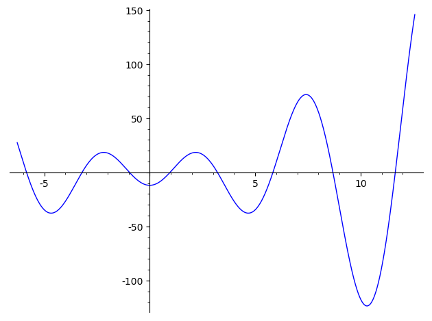

```python
fun = x^2 * cos(x)
plot(derivative(fun,x,4), (x,-2*pi,4*pi))
```

En todos los ejemplos anteriores, el primer argumento de `derivative` es una expresión simbólica. También puede ser una función simbólica, en cuyo caso no hace falta especificar la variable de derivación y el resultado, además, vuelve a ser una función simbólica:

```python
f(x) = x^2 * cos(x)       # se define f como función simbólica
d4f = derivative(f,x,4)   # o bien d4f = derivative(f,4); cálculo de la derivada cuarta
show(d4f)                 # d4f es una función simbólica...
d4f(pi/4)                 # que se puede evaluar en pi/4
```

$$\newcommand{\Bold}[1]{\mathbf{#1}}x \ {\mapsto}\ x^{2} \cos\left(x\right) + 8 \, x \sin\left(x\right) - 12 \, \cos\left(x\right)$$

$$\newcommand{\Bold}[1]{\mathbf{#1}}\frac{1}{32} \, \sqrt{2} \pi^{2} + \sqrt{2} \pi - 6 \, \sqrt{2}$$

Volver al índice

### Polinomios de Taylor

Dada una función $f$ derivable $n$ veces en un punto $x_0$, la función `taylor`, que también actúa como método, halla el polinomio de Taylor de $f$ en $x_0$ de grado $n$. La sintaxis es

> `taylor`(`fun`, `x`, $x_0$, $n$)   o bien   `fun`.`taylor`(`x`, $x_0$, $n$)

siendo `fun` una expresión simbólica que proporciona $f(x)$. Análogamente, el desarrollo limitado de $f$ de orden $n-1$ en $x_0$ se obtiene con el método `series`, que se usa como sigue:

> `fun`.`series`(`x==`$x_0$, $n$)

El último término del desarrollo limitado es el resto en forma infinitesimal. Se puede eliminar con el método `truncate`, quedando el polinomio de Taylor. En otras palabras, `fun.taylor(x,x0,n)` y `fun.series(x==x0,n+1).truncate()` dan el mismo resultado. Consideremos, por ejemplo, la función $f(x)=\cos^2 x$. Obtenemos primero su polinomio de MacLaurin de grado $6$:

```python
%display latex
fun = cos(x)^2
taylor(fun,x,0,6)
```

$$\newcommand{\Bold}[1]{\mathbf{#1}}-\frac{2}{45} \, x^{6} + \frac{1}{3} \, x^{4} - x^{2} + 1$$

Y ahora el correspondiente desarrollo limitado:

```python
fun.series(x==0,7)
```

$$\newcommand{\Bold}[1]{\mathbf{#1}}1 + {(-1)} x^{2} + \frac{1}{3} x^{4} + {(-\frac{2}{45})} x^{6} + \mathcal{O}\left(x^{7}\right)$$

Pongamos otro ejemplo. Sean $f(x)=3(x-1)e^{2x}+3\operatorname{sen} x+3$ y $g(x)=x\log(\cos x)$. Hallamos sus polinomios de MacLaurin de grado $3$:

```python
f = 3*(x-1)*exp(2*x) + 3*sin(x) +3
g = x * log(cos(x))
pf = f.taylor(x,0,3)
pg = g.taylor(x,0,3)
show(html("Polinomio de MacLaurin de $f$ de grado 3"))
show(pf)
show(html("Polinomio de MacLaurin de $g$ de grado 3"))
show(pg)
```

Polinomio de MacLaurin de $f$ de grado 3

$$\newcommand{\Bold}[1]{\mathbf{#1}}\frac{3}{2} \, x^{3}$$

Polinomio de MacLaurin de $g$ de grado 3

$$\newcommand{\Bold}[1]{\mathbf{#1}}-\frac{1}{2} \, x^{3}$$

Como aplicación, del resultado de la celda precedente podríamos concluir que $$ \lim_{x\to0} \frac{f(x)}{g(x)} = \lim_{x\to0}\frac{3(x-1)e^{2x}+3\operatorname{sen} x+3}{x\log(\cos x)} = \lim_{x\to0} \frac{3x^3/2}{-x^3/2}=-3, $$ resultado al que, no obstante, se puede llegar directamente con la función `limit`:

```python
limit(f/g, x=0)
```

$$\newcommand{\Bold}[1]{\mathbf{#1}}-3$$

Volver al índice

## Integración

La integración de una función $f$ se realiza mediante la función, y método, `integral` o su sinónimo `integrate`. Para obtener la integral indefinida de $f$, la sintaxis es

> `integral(fun, x)` o `fun.integral(x)`

donde `fun` es una expresión simbólica que proporciona $f(x)$. Análogamente, para hallar la integral definida de $f$ en un intervalo $[a,b]$, esto es, $\int_a^b f(x)\,dx$, se emplea una de las siguientes variantes:

> `integral`(`fun`, `x`, $a$, $b$)    `integral`(`fun`, (`x`, $a$, $b$))    `fun`.`integral`(`x`, $a$, $b$)

La función `integral` admite la opción `algorithm` para escoger el módulo de SageMath que efectúa el cálculo. Por omisión, se toma `algorithm="maxima"`. Otros posibles valores son `"sympy"` y `"giac"`.

SageMath puede trabajar con integrales impropias. En particular, los extremos de integración pueden ser `-oo` y `+oo`, o bien `-infinity` y `+infinity`.

Hallamos primero $\int \operatorname{sen}^2 x\, \cos^4 x \,dx$:

```python
%display latex
integral(sin(x)^2*cos(x)^4, x)
```

$$\newcommand{\Bold}[1]{\mathbf{#1}}\frac{1}{48} \, \sin\left(2 \, x\right)^{3} + \frac{1}{16} \, x - \frac{1}{64} \, \sin\left(4 \, x\right)$$

Y ahora $\displaystyle\int \frac{x^4-7 x^3+19 x^2-19 x+3}{x^3-5 x^2+9 x-5}\,dx$

```python
fun = (x^4-7*x^3+19*x^2-19*x+3) / (x^3-5*x^2+9*x-5)
fun.integral(x)
```

$$\newcommand{\Bold}[1]{\mathbf{#1}}\frac{1}{2} \, x^{2} - 2 \, x + \frac{5}{2} \, \arctan\left(x - 2\right) + \frac{3}{4} \, \log\left(x^{2} - 4 \, x + 5\right) - \frac{3}{2} \, \log\left(x - 1\right)$$

Vamos a calcular un par de integrales definidas. Las propias celdas de salida indican de qué integrales se trata:

```python
# Cálculo de la integral
f = (1-exp(x))/(1+exp(x))
val_int_f = integral(f, (x, 0, log(2))).simplify_log()

# Salida
int_f = fr"$\displaystyle\int_0^{{\log 2}} \frac{{1-e^x}}{{1+e^x}}\,dx={latex(val_int_f)}$"
show(html(int_f))
```

$\displaystyle\int_0^{\log 2} \frac{1-e^x}{1+e^x}\,dx=\log\left(\frac{8}{9}\right)$

```python
# Cálculo de la integral
f = (2-x)*cos(pi*x)
val_int_f = integral(f, (x, 1/2, 2)).simplify_rational()

# Salida
int_f = fr"$\displaystyle\int_{{1/2}}^2 (2-x)\cos(\pi x)\,dx\,dx={latex(val_int_f)}$"
show(html(int_f))
```

$\displaystyle\int_{1/2}^2 (2-x)\cos(\pi x)\,dx\,dx=-\frac{3 \, \pi + 2}{2 \, \pi^{2}}$

Veamos una integral impropia de 1.ª especie, en concreto, $\displaystyle\int_0^{+\infty} \frac{\operatorname{sen}x}{x}\,dx$:

```python
integral(sin(x)/x, (x,0,+oo))
```

$$\newcommand{\Bold}[1]{\mathbf{#1}}\frac{1}{2} \, \pi$$

Terminamos con $\displaystyle\int_2^5 \sqrt{\frac{5-x}{x-2}}\,dx$, que es una integral impropia de 2.ª especie:

```python
integral(sqrt((5-x)/(x-2)), (x,2,5))
```

$$\newcommand{\Bold}[1]{\mathbf{#1}}\frac{3}{2} \, \pi$$

Con suma frecuencia se encuentran funciones que no es posible o conveniente integrar de forma analítica. Así ocurre si el tiempo de cómputo es muy elevado o si las primitivas son excesivamente complicadas o no son expresables mediante funciones elementales. Es el caso de la integral $$ \int_0^3 \sqrt{\frac{2+x^2}{1+x^2}}\,dx. $$ Si intentamos calcularla, SageMath devuelve como resultado la propia integral tras una espera que puede ser prolongada:

```python
integrate(sqrt((2+x^2)/(1+x^2)), x, 0, 3)
```

$$\newcommand{\Bold}[1]{\mathbf{#1}}\int_{0}^{3} \frac{\sqrt{x^{2} + 2}}{\sqrt{x^{2} + 1}}\,{d x}$$

En situaciones así, se puede tratar de obtener, al menos, un valor aproximado de la integral definida mediante algún algoritmo de *integración numérica*. SageMath proporciona con tal fin el método `nintegral` y la función `numerical_integral` cuya sintaxis es

> `fun`.`nintegral`(`x`, $a$, $b$)   `numerical_integral`(`fun`, $a$, $b$)

En ambos casos se obtiene una tupla cuyo primer elemento es la aproximación de la integral y el segundo es el error estimado. El método `nintegral` devuelve además el número de evaluaciones del integrando y un código de error (si su valor es $0$, el cómputo se ha realizado sin problemas). Las órdenes `sage.calculus.calculus.nintegral?` y `numerical_integral?` dan más información sobre su uso y opciones.

```python
fun = sqrt((2+x^2)/(1+x^2))
fun.nintegrate(x, 0, 3)
```

$$\newcommand{\Bold}[1]{\mathbf{#1}}\left(3.552403506937089, 7.94864151295394 \times 10^{-09}, 21, 0\right)$$

```python
numerical_integral(fun, 0, 3)
```

$$\newcommand{\Bold}[1]{\mathbf{#1}}\left(3.552403506937085, 3.943960166160704 \times 10^{-14}\right)$$

Así pues, podemos ahora asegurar que $$ \int_0^3 \sqrt{\frac{2+x^2}{1+x^2}}\,dx\approx 3.5524035069. $$

Volver al índice

**Celda de configuración**. La evaluación de la celda siguiente cambia el formato por omisión de este cuaderno.

```python
# Se desactiva primero la acción de %display latex, si estuviera activa
%display plain
```

```python
%%html
<style>
h1{text-align: center; color: rgb(185,74,72);}
h2{text-align: center; color: rgb(0,102,0); padding: 0.25em 0;
   border: 2px solid rgb(0,191,0); border-width: 2px 0;}
h3{border-bottom: 2px solid rgb(153,153,153);}
h4{color: rgb(58,135,173); font-size: 115%!important;
   font-weight: bold!important;}
.text_cell_render{font-family: "Trebuchet MS",Geneva,sans-serif;
                  font-size: 110%; line-height: 1.5;}
.MathJax_Display{margin: 0.5em 0;}
</style>
```

Realizado por Juan José Torrens para la asignatura de **Cálculo II**  
Grados de **Ciencias** y de **Ciencia de Datos**  
Universidad Pública de Navarra  
Última versión: 14-1-2021